# Four Frameworks of Statistical Analyses

Marc Los Huertos

EA030 · Compiled 2026-04-08

EA030 — Basic Statistics — Module 02

# Four Frameworks of Statistical Analysis

**Prof. Marc Los Huertos** • Pomona College

← Back to Basic Statistics

Overview ANOVA / t-test Linear Regression Chi-square Logistic Regression Choosing a Test

> **What this module covers.** Every statistical test you will encounter in environmental science fits into one of four frameworks determined by a single question: *what type of variable is your outcome (dependent), and what type of variable is your predictor (independent)?* This module maps the landscape, then walks through each framework in depth with environmental examples, diagnostic plots, and worked R code.

## The Organising Principle

Before running any analysis, ask two questions:

1. **What kind of variable is my dependent (response) variable?** Is it a measurement on a continuous scale, or does it represent a category or binary outcome?
2. **What kind of variable is my independent (predictor) variable?** Is it a group label (categorical), or a quantity that varies smoothly (continuous)?

The answers place you in exactly one of four cells:

|  | Independent: **Categorical** groups, treatments, species, sites | Independent: **Continuous** temperature, concentration, time |
| --- | --- | --- |
| Dependent: **Continuous** mass, pH, height, PM2.5 | Framework I t-test & ANOVA Compare means across two or more groups. *Do burned and unburned plots differ in soil nitrogen?* Jump to section ↓ | Framework II Linear Regression Model a straight-line relationship between two quantities. *Does temperature predict dissolved oxygen?* Jump to section ↓ |
| Dependent: **Categorical** present/absent, survived/died | Framework III Chi-square Test Test whether category frequencies differ between groups. *Is species presence associated with habitat type?* Jump to section ↓ | Framework IV Logistic Regression Model the probability of a binary outcome from a continuous predictor. *Does pollution concentration predict fish mortality?* Jump to section ↓ |

**📌 The core logic is the same in every framework**

Every test below asks the same fundamental question: **is the pattern in my data larger than what chance alone would produce?** The answer is formalised as a *test statistic* and a *p-value*. What differs is how the test statistic is computed — because the geometry of the data changes depending on variable types.

## Framework I — t-test and ANOVA

**When to use it:** Your response variable is continuous (a measurement), and your predictor is a categorical group variable.

- **Two groups** → use a **t-test**
- **Three or more groups** → use **one-way ANOVA** (or its non-parametric equivalent, the Kruskal-Wallis test, when assumptions are violated)

### The core question

Is the difference in group means large enough — relative to the within-group variability — that it is unlikely to have arisen by chance?

$$t = \frac{\bar{x}_1 -
\bar{x}_2}{\sqrt{\frac{s_1^2}{n_1} + \frac{s_2^2}{n_2}}}$$

For ANOVA, the same logic is generalised using the **F-ratio**: variance *between* groups divided by variance *within* groups.

$$F =
\frac{MS_{\text{between}}}{MS_{\text{within}}}$$

A large F means the group means are more spread out than individual observations within groups — evidence against the null hypothesis that all group means are equal.

### Environmental example: soil nitrogen across land-use types

```r
set.seed(42)
# Soil total nitrogen (g/kg) at three land-use types
nitrogen <- data.frame(
  landuse = rep(c("Forest", "Grassland", "Cropland"), each = 25),
  N_gkg   = c(
    rnorm(25, mean = 4.8, sd = 0.7),   # Forest — highest
    rnorm(25, mean = 3.2, sd = 0.9),   # Grassland
    rnorm(25, mean = 1.9, sd = 0.6)    # Cropland — lowest
  )
)
```

#### Step 1 — Visualise the groups

Always plot your data before running any test. Boxplots show the median, interquartile range, and any outliers simultaneously.

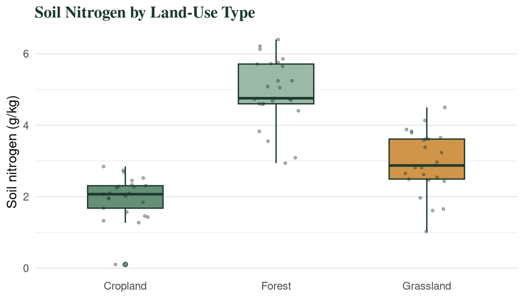

Soil nitrogen (g/kg) across three land-use types. The horizontal bar is the median; the box spans the IQR; whiskers extend to 1.5×IQR. Cropland shows consistently lower nitrogen than forest.

```r
ggplot(nitrogen, aes(x = landuse, y = N_gkg, fill = landuse)) +
  geom_boxplot(width = 0.5, outlier.shape = 21, outlier.size = 1.8,
               colour = "#1e3a2f", alpha = 0.85) +
  geom_jitter(width = 0.15, size = 0.9,
              colour = "#1e3a2f", alpha = 0.35) +
  scale_fill_manual(values = c("#4a7c5e", "#8aad96", "#c8832a")) +
  labs(x = NULL, y = "Soil nitrogen (g/kg)",
       title = "Soil Nitrogen by Land-Use Type") +
  theme_minimal(base_size = 13) +
  theme(legend.position = "none",
        panel.grid.major.x = element_blank(),
        plot.title = element_text(family = "serif", face = "bold",
                                  colour = "#1e3a2f"))
```

#### Step 2 — Run the ANOVA

```r
model_aov <- aov(N_gkg ~ landuse, data = nitrogen)
summary(model_aov)
```

```
##             Df Sum Sq Mean Sq F value Pr(>F)
## landuse      2 112.48   56.24    88.7 <2e-16 ***
## Residuals   72  45.65    0.63
## ---
## Signif. codes:  0 '***' 0.001 '**' 0.01 '*' 0.05 '.' 0.1 ' ' 1
```

The F-statistic and its p-value tell you whether *any* groups differ. A significant ANOVA only tells you that the group means are not all equal — it does not tell you *which pairs* differ.

#### Step 3 — Post-hoc comparisons

When ANOVA is significant, use **Tukey’s Honest Significant Difference (HSD)** test to identify which specific pairs of groups differ, while controlling the overall Type I error rate.

```r
TukeyHSD(model_aov)
```

```
##   Tukey multiple comparisons of means
##     95% family-wise confidence level
##
## Fit: aov(formula = N_gkg ~ landuse, data = nitrogen)
##
## $landuse
##                          diff        lwr       upr    p adj
## Forest-Cropland     2.9456297  2.4066573  3.484602 0.000000
## Grassland-Cropland  0.9813626  0.4423903  1.520335 0.000126
## Grassland-Forest   -1.9642671 -2.5032394 -1.425295 0.000000
```

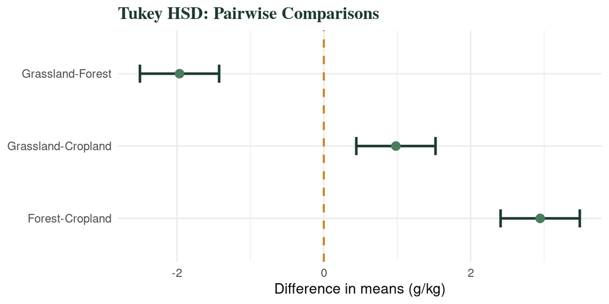

Tukey HSD 95% confidence intervals for all pairwise differences. Intervals that do not cross zero indicate a statistically significant difference between those groups.

#### Checking assumptions

ANOVA rests on three assumptions. Always check them with diagnostic plots.

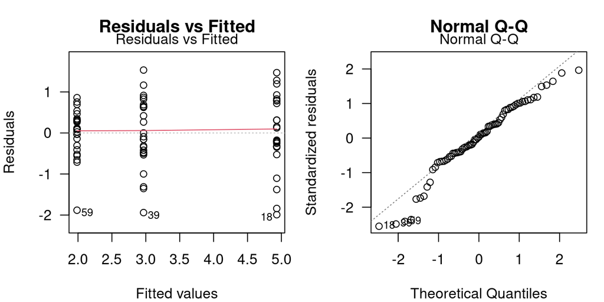

Left: residuals should scatter randomly around zero (no pattern = good). Right: residuals on a Q-Q plot should follow the diagonal line (normality check).

```r
par(mfrow = c(1, 2), mar = c(4, 4, 3, 1), las = 1)
plot(model_aov, which = 1, main = "Residuals vs Fitted")
plot(model_aov, which = 2, main = "Normal Q-Q")
```

```r
par(mfrow = c(1, 1))
```

**⚠️ When ANOVA assumptions are violated**

If residuals are strongly non-normal or variances are very unequal across groups, consider: **(1)** log-transforming the response variable (common for skewed environmental data like concentrations), **(2)** using Welch’s ANOVA (`oneway.test()`) which does not assume equal variances, or **(3)** the non-parametric **Kruskal-Wallis test** (`kruskal.test()`), which tests whether group medians differ without assuming normality.

**⚙️ Two-group case: the t-test**  
When you have exactly two groups, `t.test(y ~ group, data = df)` is equivalent to a two-group ANOVA (F = t²). Use `var.equal = TRUE` if Levene’s test confirms equal variances; otherwise the default Welch correction is safer.

## Framework II — Linear Regression

**When to use it:** Both your response and predictor are continuous. You want to describe *how much* the response changes per unit increase in the predictor, and test whether that relationship is stronger than chance.

### The model

$$Y_i = \beta_0 + \beta_1 X_i +
\varepsilon_i \qquad \varepsilon_i \sim \mathcal{N}(0,\,
\sigma^2)$$

- $\beta_0$ — **intercept**: predicted value of Y when X = 0
- $\beta_1$ — **slope**: expected change in Y for a one-unit increase in X
- $\varepsilon_i$ — **residuals**: the part of Y not explained by X

The parameters are estimated by **Ordinary Least Squares (OLS)**: choosing the line that minimises the sum of squared vertical distances between observed and predicted values.

### Environmental example: water temperature and dissolved oxygen

Dissolved oxygen (DO) decreases as water warms — a critical relationship for aquatic organisms.

```r
set.seed(7)
n_obs <- 60
temp_C <- runif(n_obs, min = 10, max = 28)          # water temperature (°C)
DO_mgl <- 14.6 - 0.38 * temp_C + rnorm(n_obs, 0, 0.6)  # DO (mg/L); ~real physics
stream <- data.frame(temp_C, DO_mgl)
```

#### Step 1 — Scatterplot with regression line

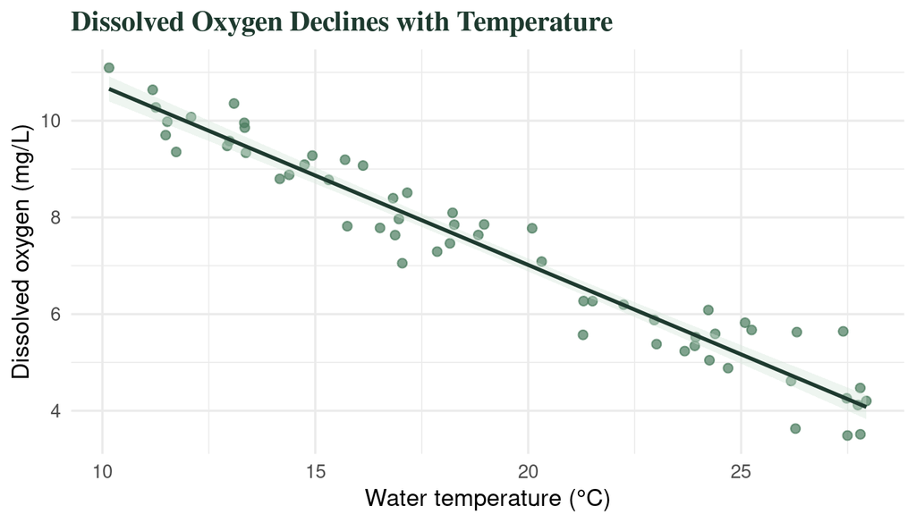

```r
ggplot(stream, aes(temp_C, DO_mgl)) +
  geom_point(colour = "#4a7c5e", alpha = 0.7, size = 2) +
  geom_smooth(method = "lm", colour = "#1e3a2f", fill = "#d4e6da",
              linewidth = 1, se = TRUE) +
  labs(x = "Water temperature (°C)", y = "Dissolved oxygen (mg/L)",
       title = "Dissolved Oxygen Declines with Temperature") +
  theme_minimal(base_size = 13) +
  theme(plot.title = element_text(family = "serif", face = "bold",
                                  colour = "#1e3a2f"))
```

#### Step 2 — Fit the model and read the output

```r
model_lm <- lm(DO_mgl ~ temp_C, data = stream)
summary(model_lm)
```

```
##
## Call:
## lm(formula = DO_mgl ~ temp_C, data = stream)
##
## Residuals:
##      Min       1Q   Median       3Q      Max
## -1.06271 -0.38220 -0.01219  0.37904  1.36342
##
## Coefficients:
##             Estimate Std. Error t value Pr(>|t|)
## (Intercept)  14.4164     0.2442   59.03   <2e-16 ***
## temp_C       -0.3700     0.0122  -30.33   <2e-16 ***
## ---
## Signif. codes:  0 '***' 0.001 '**' 0.01 '*' 0.05 '.' 0.1 ' ' 1
##
## Residual standard error: 0.5137 on 58 degrees of freedom
## Multiple R-squared:  0.9407, Adjusted R-squared:  0.9397
## F-statistic: 919.7 on 1 and 58 DF,  p-value: < 2.2e-16
```

**Reading the output:**

```r
coef(model_lm)
```

```
## (Intercept)      temp_C
##   14.416393   -0.370006
```

```r
confint(model_lm)   # 95% CIs on the coefficients
```

```
##                  2.5 %     97.5 %
## (Intercept) 13.9275506 14.9052357
## temp_C      -0.3944282 -0.3455837
```

#### Step 3 — Partition the variance: what does R² mean?

```r
# How much variance does the model explain?
ss_total   <- sum((stream$DO_mgl - mean(stream$DO_mgl))^2)
ss_resid   <- sum(residuals(model_lm)^2)
ss_model   <- ss_total - ss_resid
r_sq       <- ss_model / ss_total

cat("SS Total :", round(ss_total, 2), "\n")
```

```
## SS Total : 258.03
```

```r
cat("SS Model :", round(ss_model, 2), "\n")
```

```
## SS Model : 242.72
```

```r
cat("SS Resid :", round(ss_resid, 2), "\n")
```

```
## SS Resid : 15.31
```

```r
cat("R²       :", round(r_sq, 3), " (=", round(r_sq*100, 1), "% variance explained)\n")
```

```
## R²       : 0.941  (= 94.1 % variance explained)
```

#### Step 4 — Diagnostic plots

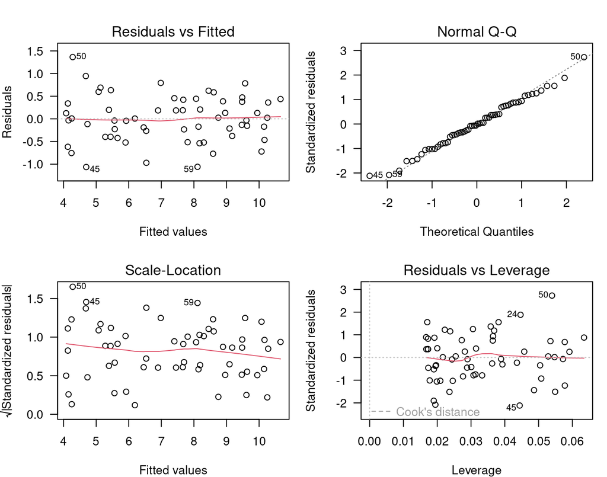

Regression diagnostics. Top-left: residuals vs fitted — look for random scatter with no funnel shape (homoscedasticity). Top-right: Q-Q plot — residuals should follow the diagonal. Bottom: Scale-Location confirms homoscedasticity; Cook’s Distance flags high-influence observations.

```r
par(mfrow = c(2, 2), mar = c(4, 4, 3, 1), las = 1)
plot(model_lm)
```

```r
par(mfrow = c(1, 1))
```

**📌 Correlation vs. regression — what is the difference?**

**Correlation** (Pearson’s *r*) quantifies the *strength and direction* of a linear relationship. It is symmetric: cor(X, Y) = cor(Y, X).

**Regression** quantifies the *rate of change*: how many units does Y change per unit increase in X? It is asymmetric — regressing Y on X gives a different line than regressing X on Y.

Use correlation when you simply want to know “are these related?” Use regression when you want to predict Y from X or estimate the effect size. Note: $r^2 = R^2$ in simple linear regression — they are the same quantity.

**⚠️ Association ≠ causation** A significant slope does not prove that X causes Y. Temperature and dissolved oxygen have a known physical mechanism. But in many environmental datasets, confounding variables drive apparent correlations. Causal inference requires careful study design, not just a significant p-value.

## Framework III — Chi-square Test

**When to use it:** Both your response and predictor are categorical. You have counts of observations falling into the cells of a contingency table and want to test whether the distribution of one variable depends on the other.

### The core question

If the two variables were independent, what counts would we *expect* in each cell? The chi-square statistic measures how far observed counts deviate from expected:

$$\chi^2 = \sum_{\text{all cells}}
\frac{(O - E)^2}{E}$$

where $O$ = observed count and $E = \frac{(\text{row total}) \times (\text{col total})}{\text{grand total}}$.

### Environmental example: species presence by habitat type

Is the presence of a focal riparian plant species associated with habitat type (riparian buffer vs. degraded bank)?

```r
set.seed(3)
n_sites <- 120

habitat  <- rep(c("Riparian buffer", "Degraded bank"), each = n_sites / 2)
# Species more likely in intact riparian buffer
present  <- c(rbinom(60, 1, prob = 0.72),   # buffer
              rbinom(60, 1, prob = 0.31))    # degraded

ecology <- data.frame(habitat, present = factor(present, labels = c("Absent","Present")))
```

#### Step 1 — Build the contingency table

```r
(ct <- table(ecology$habitat, ecology$present))
```

```
##
##                   Absent Present
##   Degraded bank       39      21
##   Riparian buffer     14      46
```

```r
# Row proportions: P(Present | habitat)
prop.table(ct, margin = 1) |> round(2)
```

```
##
##                   Absent Present
##   Degraded bank     0.65    0.35
##   Riparian buffer   0.23    0.77
```

#### Step 2 — Visualise the association

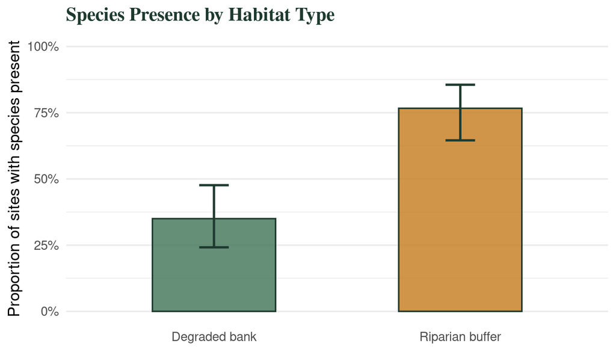

Proportion of sites where the focal species is present, by habitat type. Error bars are 95% Wilson confidence intervals. The difference in detection rates is visually clear.

```r
prop_df <- ecology |>
  group_by(habitat) |>
  summarise(
    n       = n(),
    x       = sum(present == "Present"),
    prop    = x / n,
    # Wilson CI
    lower   = (prop + qnorm(0.975)^2 / (2*n) -
                 qnorm(0.975) * sqrt(prop*(1-prop)/n + qnorm(0.975)^2/(4*n^2))) /
              (1 + qnorm(0.975)^2 / n),
    upper   = (prop + qnorm(0.975)^2 / (2*n) +
                 qnorm(0.975) * sqrt(prop*(1-prop)/n + qnorm(0.975)^2/(4*n^2))) /
              (1 + qnorm(0.975)^2 / n)
  )

ggplot(prop_df, aes(habitat, prop, fill = habitat)) +
  geom_col(width = 0.5, colour = "#1e3a2f", alpha = 0.85) +
  geom_errorbar(aes(ymin = lower, ymax = upper), width = 0.12,
                linewidth = 0.9, colour = "#1e3a2f") +
  scale_fill_manual(values = c("#4a7c5e", "#c8832a")) +
  scale_y_continuous(labels = scales::percent_format(), limits = c(0, 1)) +
  labs(x = NULL, y = "Proportion of sites with species present",
       title = "Species Presence by Habitat Type") +
  theme_minimal(base_size = 13) +
  theme(legend.position = "none",
        panel.grid.major.x = element_blank(),
        plot.title = element_text(family = "serif", face = "bold",
                                  colour = "#1e3a2f"))
```

#### Step 3 — Run the chi-square test

```r
chisq.test(ct)
```

```
##
##  Pearson's Chi-squared test with Yates' continuity correction
##
## data:  ct
## X-squared = 19.465, df = 1, p-value = 1.025e-05
```

```r
# Always check expected counts — all should be ≥ 5 for chi-square to be valid
chisq.test(ct)$expected
```

```
##
##                   Absent Present
##   Degraded bank     26.5    33.5
##   Riparian buffer   26.5    33.5
```

#### Step 4 — Effect size: Cramér’s V

A significant chi-square only tells you there is an association; it does not tell you how *strong* it is. Cramér’s V standardises the chi-square statistic to a 0–1 scale.

```r
chi_val <- chisq.test(ct)$statistic
n_total <- sum(ct)
k       <- min(nrow(ct), ncol(ct))   # min(rows, cols)
cramers_v <- sqrt(chi_val / (n_total * (k - 1)))
cat("Cramér's V =", round(cramers_v, 3),
    " (0 = no association, 1 = perfect association)\n")
```

```
## Cramér's V = 0.403  (0 = no association, 1 = perfect association)
```

**📌 When to use Fisher’s Exact Test instead**

The chi-square test requires that all **expected** cell counts are ≥ 5. When you have small samples or rare events (common in species detection studies), use `fisher.test(ct)` instead. Fisher’s exact test works with any sample size and is preferred for 2×2 tables with small marginal totals.

**⚙️ Chi-square vs. logistic regression for 2×2 tables**  
Chi-square tests association. Logistic regression models the *probability* of the outcome and produces an **odds ratio** — the most useful effect-size measure for categorical outcomes. For a single binary predictor, both give the same p-value; logistic regression adds the odds ratio and allows control for confounders. See Framework IV.

## Framework IV — Logistic Regression

**When to use it:** Your response is binary (0/1, absent/present, survived/died), and your predictor is continuous (or a mix of continuous and categorical).

### Why not just use linear regression on 0/1 data?

A linear model can predict probabilities below 0 or above 1, which is nonsensical. Logistic regression solves this by modelling the **log-odds** (logit) of the outcome as a linear function of the predictors:

$$\log\!\left(\frac{p}{1-p}\right) =
\beta_0 + \beta_1 X$$

Solving for $p$ gives the **logistic (sigmoid) curve** — bounded between 0 and 1:

$$p = \frac{1}{1 + e^{-(\beta_0 + \beta_1
X)}}$$

### Environmental example: fish mortality as a function of pollutant concentration

At what pollutant concentration does survival probability drop below 50%?

```r
set.seed(11)
n_fish <- 120
conc   <- runif(n_fish, min = 0, max = 10)   # pollutant (mg/L)
# True model: logit(p) = 2.5 - 0.8*conc  →  LC50 ≈ 3.1 mg/L
log_odds <- 2.5 - 0.8 * conc
prob     <- 1 / (1 + exp(-log_odds))
survived <- rbinom(n_fish, 1, prob)

fish <- data.frame(conc, survived)
```

#### Step 1 — Visualise the binary outcome

Binary data cannot be plotted as a scatterplot without modification. Jitter the points vertically and overlay the model curve.

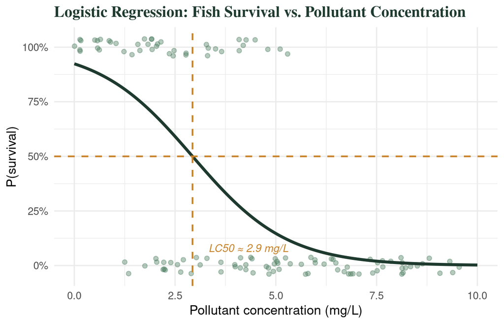

Fish survival (1 = survived, 0 = died) vs. pollutant concentration. Points are jittered to reduce overplotting. The curve is the fitted logistic regression model; the dashed line marks 50% survival probability and the estimated LC50.

```r
model_glm <- glm(survived ~ conc, data = fish, family = binomial)

# Prediction curve
pred_df <- data.frame(conc = seq(0, 10, length.out = 300))
pred_df$prob <- predict(model_glm, newdata = pred_df, type = "response")

# LC50: concentration where p = 0.5  → conc = -b0/b1
lc50 <- -coef(model_glm)[1] / coef(model_glm)[2]

ggplot(fish, aes(conc, survived)) +
  geom_jitter(height = 0.04, width = 0, alpha = 0.4, size = 1.8,
              colour = "#4a7c5e") +
  geom_line(data = pred_df, aes(y = prob),
            colour = "#1e3a2f", linewidth = 1.4) +
  geom_hline(yintercept = 0.5, linetype = "dashed",
             colour = "#c8832a", linewidth = 0.8) +
  geom_vline(xintercept = lc50, linetype = "dashed",
             colour = "#c8832a", linewidth = 0.8) +
  annotate("text", x = lc50 + 0.4, y = 0.08,
           label = paste0("LC50 ≈ ", round(lc50, 1), " mg/L"),
           colour = "#c8832a", hjust = 0, size = 3.8, fontface = "italic") +
  scale_y_continuous(labels = scales::percent_format(),
                     breaks = c(0, 0.25, 0.5, 0.75, 1)) +
  labs(x = "Pollutant concentration (mg/L)",
       y = "P(survival)",
       title = "Logistic Regression: Fish Survival vs. Pollutant Concentration") +
  theme_minimal(base_size = 13) +
  theme(plot.title = element_text(family = "serif", face = "bold",
                                  colour = "#1e3a2f"))
```

#### Step 2 — Fit and interpret the model

```r
summary(model_glm)
```

```
##
## Call:
## glm(formula = survived ~ conc, family = binomial, data = fish)
##
## Deviance Residuals:
##     Min       1Q   Median       3Q      Max
## -1.8141  -0.6032  -0.1945   0.6144   2.0656
##
## Coefficients:
##             Estimate Std. Error z value Pr(>|z|)
## (Intercept)   2.4955     0.5589   4.465 8.01e-06 ***
## conc         -0.8509     0.1575  -5.404 6.53e-08 ***
## ---
## Signif. codes:  0 '***' 0.001 '**' 0.01 '*' 0.05 '.' 0.1 ' ' 1
##
## (Dispersion parameter for binomial family taken to be 1)
##
##     Null deviance: 156.589  on 119  degrees of freedom
## Residual deviance:  98.186  on 118  degrees of freedom
## AIC: 102.19
##
## Number of Fisher Scoring iterations: 5
```

**Reading the output:**

The coefficients are on the **log-odds scale**, which is hard to interpret directly. Convert to **odds ratios** by exponentiating:

```r
exp(coef(model_glm))          # odds ratios
```

```
## (Intercept)        conc
##  12.1275073   0.4270205
```

```r
exp(confint(model_glm))       # 95% CIs on odds ratios
```

```
##                 2.5 %     97.5 %
## (Intercept) 4.3887636 40.0315042
## conc        0.3025173  0.5637595
```

- `(Intercept)` exponentiated: the odds of survival when concentration = 0
- `conc` exponentiated: for each 1 mg/L increase in concentration, the **odds of survival** are multiplied by this factor (< 1 = decreasing odds)

```r
lc50_val <- -coef(model_glm)["(Intercept)"] / coef(model_glm)["conc"]
cat("Estimated LC50:", round(lc50_val, 2), "mg/L\n")
```

```
## Estimated LC50: 2.93 mg/L
```

#### Step 3 — Model fit statistics

Unlike linear regression, logistic regression has no single R² analogue. Use **pseudo-R²** (McFadden’s) and the **Akaike Information Criterion (AIC)** to assess and compare models.

```r
# Null model (intercept only) for comparison
model_null <- glm(survived ~ 1, data = fish, family = binomial)

# McFadden's pseudo-R²
mcfadden_r2 <- 1 - (logLik(model_glm) / logLik(model_null))
cat("McFadden R² =", round(mcfadden_r2, 3), "\n")
```

```
## McFadden R² = 0.373
```

```r
# AIC (lower = better fit, penalises complexity)
cat("AIC (full model) =", round(AIC(model_glm), 1), "\n")
```

```
## AIC (full model) = 102.2
```

```r
cat("AIC (null model) =", round(AIC(model_null), 1), "\n")
```

```
## AIC (null model) = 158.6
```

#### Step 4 — Classification accuracy

```r
# Classify: predict survival if p > 0.5
fish$predicted <- ifelse(
  predict(model_glm, type = "response") > 0.5, 1, 0)

conf_mat <- table(Predicted = fish$predicted, Actual = fish$survived)
conf_mat
```

```
##          Actual
## Predicted  0  1
##         0 63 13
##         1 14 30
```

```r
accuracy <- sum(diag(conf_mat)) / sum(conf_mat)
cat("Overall accuracy:", round(accuracy * 100, 1), "%\n")
```

```
## Overall accuracy: 77.5 %
```

**💡 Extending logistic regression**

Logistic regression generalises naturally:

- **Multiple predictors** — add more terms: `glm(y ~ x1 + x2 + x3, family = binomial)`
- **Interaction terms** — `x1:x2` or `x1*x2` in the formula
- **Ordered outcomes (3+ levels)** — ordinal logistic regression (`MASS::polr()`)
- **Unordered outcomes (3+ levels)** — multinomial logistic regression (`nnet::multinom()`)

The underlying principle — modelling the log-odds as a linear function — remains the same throughout.

## Choosing the Right Framework

Use this decision process before every analysis:

Framework selection guide. When in doubt: plot first, then choose.

| Dependent variable | Independent variable | Primary test | Effect size | Non-parametric alt. |
| --- | --- | --- | --- | --- |
| Continuous | Categorical (2 groups) | t-test (`t.test()`) | Cohen’s d | Wilcoxon (`wilcox.test()`) |
| Continuous | Categorical (3+ groups) | One-way ANOVA (`aov()`) | η² (eta-squared) | Kruskal-Wallis (`kruskal.test()`) |
| Binary (0/1) | Categorical | Chi-square (`chisq.test()`) | Cramér’s V | Fisher’s exact (`fisher.test()`) |
| Binary (0/1) | Continuous | Logistic regression (`glm(..., family=binomial)`) | Odds ratio | — (logistic is already non-normal) |

#### 🔑 The four frameworks — key takeaways

- **Framework I (ANOVA / t-test):** compares means across groups using the F- or t-statistic. Extend with Tukey’s HSD for pairwise comparisons. Check residual normality and equal variances.
- **Framework II (Linear regression):** estimates a slope (effect size with units). R² tells you how much variance is explained. Four diagnostic plots catch violations of OLS assumptions.
- **Framework III (Chi-square):** tests independence in a contingency table. Use Cramér’s V for effect size. Switch to Fisher’s exact test when expected counts are small.
- **Framework IV (Logistic regression):** models P(outcome) as a sigmoid function of a continuous predictor. Coefficients are log-odds; exponentiate for odds ratios. McFadden’s R² and AIC assess model fit.
- **In every framework:** visualise first, check assumptions, report effect sizes alongside p-values, and show uncertainty (CIs, not just stars).

### What’s next?

- **Describing Data** — means, SD, SE, and confidence intervals
- **t-test in depth** — worked example with course data
- **ANOVA in depth** — factorial designs and interaction effects
- **Regression in depth** — multiple predictors and model selection